# Tutorial (vignette) for the eurostat R package

2019-04-11

# R Tools for Eurostat Open Data

This [rOpenGov](http://ropengov.github.io) R package provides tools to access [Eurostat database](http://ec.europa.eu/eurostat/data/database), which you can also browse on-line for the data sets and documentation. For contact information and source code, see the [package website](http://ropengov.github.io/eurostat/).

# Installation

Release version [(CRAN)](https://cran.r-project.org/web/packages/eurostat/index.html):

```r
install.packages("eurostat")
```

Development version [(Github)](https://github.com/rOpenGov/eurostat):

```r
library(devtools)
install_github("ropengov/eurostat")
```

Overall, the eurostat package includes the following functions:

```
clean_eurostat_cache    Clean Eurostat Cache
cut_to_classes          Cuts the Values Column into Classes and
                        Polishes the Labels
dic_order               Order of Variable Levels from Eurostat
                        Dictionary.
eu_countries            Countries and Country Codes
eurostat-package        R Tools for Eurostat open data
eurostat_geodata_60_2016
                        Geospatial data of Europe from Gisco in 1:60
                        million scale from year 2016
eurotime2date           Date Conversion from Eurostat Time Format
eurotime2num            Conversion of Eurostat Time Format to Numeric
get_bibentry            Create A Data Bibliography
get_eurostat            Read Eurostat Data
get_eurostat_dic        Download Eurostat Dictionary
get_eurostat_geospatial
                        Download Geospatial Data from GISGO
get_eurostat_json       Get Data from Eurostat API in JSON
get_eurostat_raw        Download Data from Eurostat Database
get_eurostat_toc        Download Table of Contents of Eurostat Data
                        Sets
harmonize_country_code
                        Harmonize Country Code
label_eurostat          Get Eurostat Codes
search_eurostat         Grep Datasets Titles from Eurostat
tgs00026                Auxiliary Data
```

# Finding data

Function `get_eurostat_toc()` downloads a table of contents of eurostat datasets. The values in column ‘code’ should be used to download a selected dataset.

```r
# Load the package
library(eurostat)
library(rvest)

# Get Eurostat data listing
toc <- get_eurostat_toc()

# Check the first items
library(knitr)
kable(head(toc))
```

| title | code | type | last update of data | last table structure change | data start | data end | values |
| --- | --- | --- | --- | --- | --- | --- | --- |
| Database by themes | data | folder | NA | NA | NA | NA | NA |
| General and regional statistics | general | folder | NA | NA | NA | NA | NA |
| European and national indicators for short-term analysis | euroind | folder | NA | NA | NA | NA | NA |
| Business and consumer surveys (source: DG ECFIN) | ei_bcs | folder | NA | NA | NA | NA | NA |
| Consumer surveys (source: DG ECFIN) | ei_bcs_cs | folder | NA | NA | NA | NA | NA |
| Consumers - monthly data | ei_bsco_m | dataset | 28.03.2019 | 28.03.2019 | 1980M01 | 2019M03 | NA |

With `search_eurostat()` you can search the table of contents for particular patterns, e.g. all datasets related to *passenger transport*. The kable function to produces nice markdown output. Note that with the `type` argument of this function you could restrict the search to for instance datasets or tables.

```r
# info about passengers
kable(head(search_eurostat("passenger transport")))
```

| title | code | type | last update of data | last table structure change | data start | data end | values |
| --- | --- | --- | --- | --- | --- | --- | --- |
| Volume of passenger transport relative to GDP | tran_hv_pstra | dataset | 26.03.2019 | 26.03.2019 | 2000 | 2016 | NA |
| Modal split of passenger transport | tran_hv_psmod | dataset | 21.03.2019 | 21.03.2019 | 1990 | 2016 | NA |
| Air passenger transport by reporting country | avia_paoc | dataset | 09.04.2019 | 09.04.2019 | 1993 | 2018Q4 | NA |
| Air passenger transport by main airports in each reporting country | avia_paoa | dataset | 05.04.2019 | 05.04.2019 | 1993 | 2018Q4 | NA |
| Air passenger transport between reporting countries | avia_paocc | dataset | 10.04.2019 | 27.03.2019 | 1993 | 2018Q4 | NA |
| Air passenger transport between main airports in each reporting country and partner reporting countries | avia_paoac | dataset | 09.04.2019 | 27.03.2019 | 1993 | 2018Q4 | NA |

Codes for the dataset can be searched also from the [Eurostat database](http://ec.europa.eu/eurostat/data/database). The Eurostat database gives codes in the Data Navigation Tree after every dataset in parenthesis.

# Downloading data

The package supports two of the Eurostats download methods: the bulk download facility and the Web Services’ JSON API. The bulk download facility is the fastest method to download whole datasets. It is also often the only way as the JSON API has limitation of maximum 50 sub-indicators at a time and whole datasets usually exceeds that. To download only a small section of the dataset the JSON API is faster, as it allows to make a data selection before downloading.

A user does not usually have to bother with methods, as both are used via main function `get_eurostat()`. If only the table id is given, the whole table is downloaded from the bulk download facility. If also filters are defined the JSON API is used.

Here an example of indicator ‘Modal split of passenger transport’. This is the percentage share of each mode of transport in total inland transport, expressed in passenger-kilometres (pkm) based on transport by passenger cars, buses and coaches, and trains. All data should be based on movements on national territory, regardless of the nationality of the vehicle. However, the data collection is not harmonized at the EU level.

Pick and print the id of the data set to download:

```r
# For the original data, see
# http://ec.europa.eu/eurostat/tgm/table.do?tab=table&init=1&plugin=1&language=en&pcode=tsdtr210
id <- search_eurostat("Modal split of passenger transport",
                         type = "table")$code[1]
print(id)
```

[1] “t2020_rk310”

Get the whole corresponding table. As the table is annual data, it is more convient to use a numeric time variable than use the default date format:

```r
dat <- get_eurostat(id, time_format = "num")
```

Investigate the structure of the downloaded data set:

```r
str(dat)
```

```
## Classes 'tbl_df', 'tbl' and 'data.frame':    2485 obs. of  5 variables:
##  $ unit   : Factor w/ 1 level "PC": 1 1 1 1 1 1 1 1 1 1 ...
##  $ vehicle: Factor w/ 3 levels "BUS_TOT","CAR",..: 1 1 1 1 1 1 1 1 1 1 ...
##  $ geo    : Factor w/ 34 levels "AT","BE","CH",..: 1 2 3 4 5 6 7 8 9 10 ...
##  $ time   : num  1990 1990 1990 1990 1990 1990 1990 1990 1990 1990 ...
##  $ values : num  11 10.6 3.7 9.1 11.3 32.4 14.9 13.5 6 24.8 ...
```

```r
kable(head(dat))
```

| unit | vehicle | geo | time | values |
| --- | --- | --- | --- | --- |
| PC | BUS_TOT | AT | 1990 | 11.0 |
| PC | BUS_TOT | BE | 1990 | 10.6 |
| PC | BUS_TOT | CH | 1990 | 3.7 |
| PC | BUS_TOT | DE | 1990 | 9.1 |
| PC | BUS_TOT | DK | 1990 | 11.3 |
| PC | BUS_TOT | EL | 1990 | 32.4 |

Or you can get only a part of the dataset by defining `filters` argument. It should be named list, where names corresponds to variable names (lower case) and values are vectors of codes corresponding desidered series (upper case). For time variable, in addition to a `time`, also a `sinceTimePeriod` and a `lastTimePeriod` can be used.

```r
dat2 <- get_eurostat(id, filters = list(geo = c("EU28", "FI"), lastTimePeriod=1), time_format = "num")
kable(dat2)
```

[output not shown]

## Replacing codes with labels

By default variables are returned as Eurostat codes, but to get human-readable labels instead, use a `type = "label"` argument.

```r
datl2 <- get_eurostat(id, filters = list(geo = c("EU28", "FI"),
                                         lastTimePeriod = 1),
                      type = "label", time_format = "num")
kable(head(datl2))
```

[output not shown]

Eurostat codes in the downloaded data set can be replaced with human-readable labels from the Eurostat dictionaries with the `label_eurostat()` function.

```r
datl <- label_eurostat(dat)
kable(head(datl))
```

| unit | vehicle | geo | time | values |
| --- | --- | --- | --- | --- |
| Percentage | Motor coaches, buses and trolley buses | Austria | 1990 | 11.0 |
| Percentage | Motor coaches, buses and trolley buses | Belgium | 1990 | 10.6 |
| Percentage | Motor coaches, buses and trolley buses | Switzerland | 1990 | 3.7 |
| Percentage | Motor coaches, buses and trolley buses | Germany (until 1990 former territory of the FRG) | 1990 | 9.1 |
| Percentage | Motor coaches, buses and trolley buses | Denmark | 1990 | 11.3 |
| Percentage | Motor coaches, buses and trolley buses | Greece | 1990 | 32.4 |

The `label_eurostat()` allows conversion of individual variable vectors or variable names as well.

```r
label_eurostat_vars(names(datl))
```

[output not shown]

Vehicle information has 3 levels. You can check them now with:

```r
levels(datl$vehicle)
```

[output not shown]

# Selecting and modifying data

## EFTA, Eurozone, EU and EU candidate countries

To facilitate smooth visualization of standard European geographic areas, the package provides ready-made lists of the country codes used in the eurostat database for EFTA (efta_countries), Euro area (ea_countries), EU (eu_countries) and EU candidate countries (eu_candidate_countries). These can be used to select specific groups of countries for closer investigation. For conversions with other standard country coding systems, see the countrycode R package. To retrieve the country code list for EFTA, for instance, use:

```r
data(efta_countries)
kable(efta_countries)
```

| code | name | label |
| --- | --- | --- |
| IS | Iceland | Iceland |
| LI | Liechtenstein | Liechtenstein |
| NO | Norway | Norway |
| CH | Switzerland | Switzerland |

## EU data from 2012 in all vehicles:

```r
dat_eu12 <- subset(datl, geo == "European Union (current composition)" & time == 2012)
kable(dat_eu12, row.names = FALSE)
```

[output not shown]

## EU data from 2000 - 2012 with vehicle types as variables:

Reshaping the data is best done with `spread()` in `tidyr`.

```r
library("tidyr")
dat_eu_0012 <- subset(dat, geo == "EU28" & time %in% 2000:2012)
dat_eu_0012_wide <- spread(dat_eu_0012, vehicle, values)
kable(subset(dat_eu_0012_wide, select = -geo), row.names = FALSE)
```

| unit | time | BUS_TOT | CAR | TRN |
| --- | --- | --- | --- | --- |
| PC | 2000 | 10.4 | 82.5 | 7.1 |
| PC | 2001 | 10.2 | 82.8 | 7.0 |
| PC | 2002 | 9.8 | 83.4 | 6.8 |
| PC | 2003 | 9.8 | 83.6 | 6.6 |
| PC | 2004 | 9.7 | 83.5 | 6.7 |
| PC | 2005 | 9.8 | 83.4 | 6.9 |
| PC | 2006 | 9.6 | 83.4 | 7.0 |
| PC | 2007 | 9.8 | 83.1 | 7.1 |
| PC | 2008 | 9.8 | 82.9 | 7.4 |
| PC | 2009 | 9.2 | 83.7 | 7.1 |
| PC | 2010 | 9.4 | 83.5 | 7.2 |
| PC | 2011 | 9.4 | 83.2 | 7.4 |
| PC | 2012 | 9.5 | 82.9 | 7.7 |

## Train passengers for selected EU countries in 2000 - 2012

```r
dat_trains <- subset(datl, geo %in% c("Austria", "Belgium", "Finland", "Sweden")
                     & time %in% 2000:2012
                     & vehicle == "Trains")

dat_trains_wide <- spread(dat_trains, geo, values)
kable(subset(dat_trains_wide, select = -vehicle), row.names = FALSE)
```

| unit | time | Austria | Belgium | Finland | Sweden |
| --- | --- | --- | --- | --- | --- |
| Percentage | 2000 | 9.7 | 6.3 | 5.1 | 6.8 |
| Percentage | 2001 | 9.7 | 6.4 | 4.8 | 7.1 |
| Percentage | 2002 | 9.7 | 6.5 | 4.8 | 7.1 |
| Percentage | 2003 | 9.5 | 6.5 | 4.7 | 7.0 |
| Percentage | 2004 | 9.4 | 7.1 | 4.7 | 6.8 |
| Percentage | 2005 | 9.8 | 6.6 | 4.8 | 7.1 |
| Percentage | 2006 | 10.0 | 6.9 | 4.8 | 7.6 |
| Percentage | 2007 | 10.0 | 7.1 | 5.0 | 7.9 |
| Percentage | 2008 | 11.1 | 7.5 | 5.4 | 8.6 |
| Percentage | 2009 | 11.1 | 7.5 | 5.1 | 8.7 |
| Percentage | 2010 | 11.0 | 7.7 | 5.2 | 8.7 |
| Percentage | 2011 | 11.3 | 7.7 | 5.0 | 8.7 |
| Percentage | 2012 | 11.8 | 7.8 | 5.3 | 9.1 |

# Visualization

Visualizing train passenger data with `ggplot2`:

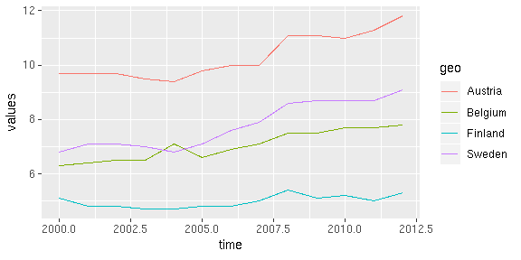

```r
library(ggplot2)
p <- ggplot(dat_trains, aes(x = time, y = values, colour = geo))
p <- p + geom_line()
print(p)
```

**Triangle plot**

Triangle plot is handy for visualizing data sets with three variables.

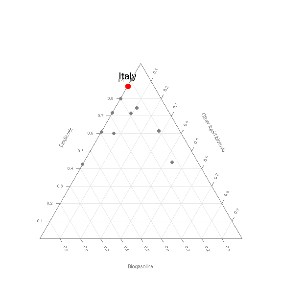

```r
library(tidyr)
library(plotrix)
library(eurostat)
library(dplyr)
library(tidyr)

# Some cleaning of the data is required
 energy3 <- get_eurostat("nrg_114a") %>%
 label_eurostat(dat) %>%
 filter(time == "2013-01-01") %>%
 mutate(geo = gsub(geo, pattern=" \\(.*", replacement="")) %>%
 select(product, geo, values) %>%
 group_by(product, geo) %>%
 summarise(svalue = sum(values)) %>%
 group_by(geo) %>%
 mutate(tvalue = sum(svalue),
 svalue = svalue/sum(svalue)) %>%
 filter(tvalue > 1000) %>% # only large countries
 spread(product, svalue)

# Triangle plot
 par(cex=0.75, mar=c(0,0,0,0))
 positions <- plotrix::triax.plot(as.matrix(energy3[, c(3,5,4)]),
                     show.grid = TRUE,
                     label.points= FALSE, point.labels = energy3$geo,
                     col.axis="gray50", col.grid="gray90",
                     pch = 19, cex.axis=0.8, cex.ticks=0.7, col="grey50")

 # Larger labels
 ind <- which(energy3$geo %in%  c("Norway", "Iceland","Denmark","Estonia", "Turkey", "Italy", "Finland"))
 df <- data.frame(positions$xypos, geo = energy3$geo)
 points(df$x[ind], df$y[ind], cex=2, col="red", pch=19)
 text(df$x[ind], df$y[ind], df$geo[ind], adj = c(0.5,-1), cex=1.5)
```

## Maps

### Disposable income of private households by NUTS 2 regions at 1:60mln resolution using tmap

The mapping examples below use [`tmap`](https://github.com/mtennekes/tmap) package.

```r
library(dplyr)
library(eurostat)
library(sf)
library(tmap)

# Download attribute data from Eurostat
sp_data <- eurostat::get_eurostat("tgs00026",
                          time_format = "raw",
                                  stringsAsFactors = FALSE) %>%
  # subset to have only a single row per geo
  dplyr::filter(time == 2010, nchar(geo) == 4) %>%
  # categorise
  dplyr::mutate(income = cut_to_classes(values, n = 5))
```

```
## Table tgs00026 cached at /tmp/RtmpZyofyh/eurostat/tgs00026_raw_code_FF.rds
```

```r
# Download geospatial data from GISCO
geodata <- get_eurostat_geospatial(output_class = "sf",
                                   resolution = "60",
                   nuts_level = 2,
                   year = 2013)
```

[output not shown]

```
## No encoding supplied: defaulting to UTF-8.
```

[output not shown]

```r
# merge with attribute data with geodata
map_data <- inner_join(geodata, sp_data)
```

Construct the map

```
## Some legend labels were too wide. These labels have been resized to 0.66, 0.62, 0.62, 0.62, 0.62. Increase legend.width (argument of tm_layout) to make the legend wider and therefore the labels larger.
```

[figure not shown]

```r
map1 <- tmap::tm_shape(geodata) +
  tmap::tm_fill("lightgrey") +
  tmap::tm_shape(map_data) +
  tmap::tm_grid() +
  tmap::tm_polygons("income", title = "Disposable household\nincomes in 2010",
                    palette = "Oranges")
print(map1)
```

Interactive maps can be generated as well

```r
# Interactive
tmap_mode("view")
map1

# Set the mode back to normal plotting
tmap_mode("plot")
print(map1)
```

```r
library(eurostat)
library(dplyr)
library(sf)
library(RColorBrewer)

# Downloading and manipulating the tabular data
print("Let us focus on year 2014 and NUTS-3 level")
```

```
## [1] "Let us focus on year 2014 and NUTS-3 level"
```

```r
euro_sf2 <- get_eurostat("tgs00026", time_format = "raw",
                         stringsAsFactors = FALSE,
             filter = list(time = "2014")) %>%

  # Subset to NUTS-3 level
  dplyr::filter(grepl("PL",geo)) %>%
  # label the single geo column
  mutate(label = paste0(label_eurostat(.)[["geo"]], "\n", values, "€"),
         income = cut_to_classes(values))

print("Download geospatial data from GISCO")
```

```
## [1] "Download geospatial data from GISCO"
```

```r
geodata <- get_eurostat_geospatial(output_class = "sf", resolution = "60", nuts_level = 2, year = 2013)
```

[output not shown]

```
## No encoding supplied: defaulting to UTF-8.
```

[output not shown]

[figure not shown]

```r
# Merge with attribute data with geodata
map_data <- inner_join(geodata, euro_sf2)
# plot map
map2 <- tm_shape(geodata) +
  tm_fill("lightgrey") +
  tm_shape(map_data, is.master = TRUE) +
  tm_polygons("income", title = "Disposable household incomes in 2014",
              palette = "Oranges", border.col = "white") +
  tm_text("NUTS_NAME", just = "center") +
  tm_scale_bar()
map2
```

### Disposable income of private households by NUTS 2 regions at 1:10mln resolution using spplot

```r
library(sp)
library(eurostat)
library(dplyr)
library(RColorBrewer)
dat <- get_eurostat("tgs00026", time_format = "raw", stringsAsFactors = FALSE) %>%
  # subsetting to year 2014 and NUTS-2 level
  dplyr::filter(time == 2014, nchar(geo) == 4) %>%
  # classifying the values the variable
  dplyr::mutate(cat = cut_to_classes(values))
```

```
## Reading cache file /tmp/RtmpZyofyh/eurostat/tgs00026_raw_code_FF.rds
```

```
## Table  tgs00026  read from cache file:  /tmp/RtmpZyofyh/eurostat/tgs00026_raw_code_FF.rds
```

```r
# Download geospatial data from GISCO
geodata <- get_eurostat_geospatial(output_class = "spdf", resolution = "10", nuts_level = 2, year = 2013)
```

[output not shown]

```
## No encoding supplied: defaulting to UTF-8.
```

```
## SpatialPolygonDataFrame at resolution 1: 10  cached at:  /tmp/RtmpZyofyh/eurostat/spdf1022013.RData
```

[output not shown]

```r
# merge with attribute data with geodata
geodata@data <- left_join(geodata@data, dat)
```

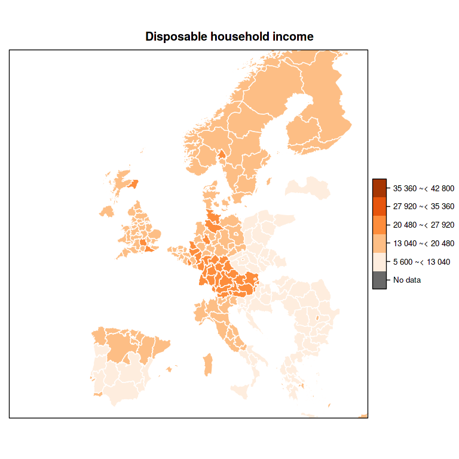

```r
# plot map
sp::spplot(obj = geodata, "cat", main = "Disposable household income",
       xlim = c(-22,34), ylim = c(35,70),
           col.regions = c("dim grey", brewer.pal(n = 5, name = "Oranges")),
       col = "white", usePolypath = FALSE)
```

### Disposable income of private households by NUTS 2 regions at 1:60mln resolution using ggplot2

```r
library(eurostat)
library(dplyr)
library(ggplot2)
dat <- get_eurostat("tgs00026", time_format = "raw", stringsAsFactors = FALSE) %>%
  # subsetting to year 2014 and NUTS-2 level
  dplyr::filter(time == 2014, nchar(geo) == 4) %>%
  # classifying the values the variable
  dplyr::mutate(cat = cut_to_classes(values))
```

```
## Reading cache file /tmp/RtmpZyofyh/eurostat/tgs00026_raw_code_FF.rds
```

```
## Table  tgs00026  read from cache file:  /tmp/RtmpZyofyh/eurostat/tgs00026_raw_code_FF.rds
```

```r
# Download geospatial data from GISCO
geodata <- get_eurostat_geospatial(resolution = "60", nuts_level = "2", year = 2013)
```

[output not shown]

```
## No encoding supplied: defaulting to UTF-8.
```

[output not shown]

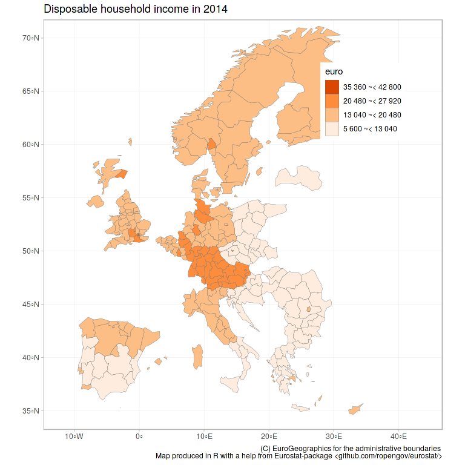

```r
# merge with attribute data with geodata
map_data <- inner_join(geodata, dat)
ggplot(data=map_data) + geom_sf(aes(fill=cat),color="dim grey", size=.1) +
    scale_fill_brewer(palette = "Oranges") +
  guides(fill = guide_legend(reverse=T, title = "euro")) +
  labs(title="Disposable household income in 2014",
       caption="(C) EuroGeographics for the administrative boundaries
                Map produced in R with a help from Eurostat-package <github.com/ropengov/eurostat/>") +
  theme_light() + theme(legend.position=c(.8,.8)) +
  coord_sf(xlim=c(-12,44), ylim=c(35,70))
```

## SDMX

Eurostat data is available also in the SDMX format. The eurostat R package does not provide custom tools for this but the generic [rsdmx](https://cran.r-project.org/web/packages/rsdmx/index.html) and [rjsdmx](https://github.com/amattioc/SDMX/wiki) R packages can be used to access data in that format when necessary:

```r
library(rsdmx)

# Data set URL
url <- "http://ec.europa.eu/eurostat/SDMX/diss-web/rest/data/cdh_e_fos/..PC.FOS1.BE/?startperiod=2005&endPeriod=2011"

# Read the data from eurostat
d <- readSDMX(url)

# Convert to data frame and show the first entries
df <- as.data.frame(d)

kable(head(df))
```

[output not shown]

# Further examples

For further examples, see the [package homepage](http://ropengov.github.io/eurostat/articles/index.html).

# Citations and related work

### Citing the data sources

Eurostat data: cite [Eurostat](http://ec.europa.eu/eurostat/).

Administrative boundaries: cite EuroGeographics

### Citing the eurostat R package

For main developers and contributors, see the [package homepage](http://ropengov.github.io/eurostat).

This work can be freely used, modified and distributed under the BSD-2-clause (modified FreeBSD) license:

```r
citation("eurostat")
```

```
##
## Kindly cite the eurostat R package as follows:
##
##   (C) Leo Lahti, Janne Huovari, Markus Kainu, Przemyslaw Biecek.
##   Retrieval and analysis of Eurostat open data with the eurostat
##   package. R Journal 9(1):385-392, 2017. Version 3.3.5 Package
##   URL: http://ropengov.github.io/eurostat Manuscript URL:
##   https://journal.r-project.org/archive/2017/RJ-2017-019/index.html
##
## A BibTeX entry for LaTeX users is
##
##   @Misc{,
##     title = {eurostat R package},
##     author = {Leo Lahti and Janne Huovari and Markus Kainu and Przemyslaw Biecek},
##     journal = {R Journal},
##     volume = {9},
##     number = {1},
##     pages = {385-392},
##     year = {2017},
##     url = {https://journal.r-project.org/archive/2017/RJ-2017-019/index.html},
##     note = {Version 3.3.5},
##   }
```

### Contact

For contact information, see the [package homepage](http://ropengov.github.io/eurostat).

# Version info